```python
import numpy as np
import matplotlib.pyplot as plt
```

# A

Ley débil de los grandes números Para ello, se utilizará la distribución uniforme en el intervalo de (0,1). Genere n=1,000,000 de valores independientes al azar x1,...,xn de esta distribución y calcule las medias aritméticas parciales sn=1/n∑i=1 hasta n xi n=1,2,...,1,000,000. Grafique la función n⟶sn uniendo los valores con una línea recta. Sea µ la media de la distribución. Trace en la misma gráfica la función constante µ y verifique gráficamente que la función n⟶sn oscila y se aproxima al valor µ conforme n crece.

```python
# Generar valores aleatorios
n = 1000000
x = np.random.uniform(0, 1, n)
```

```python
# Calcular las medias aritméticas parciales
s_n = np.cumsum(x) / np.arange(1, n+1)
```

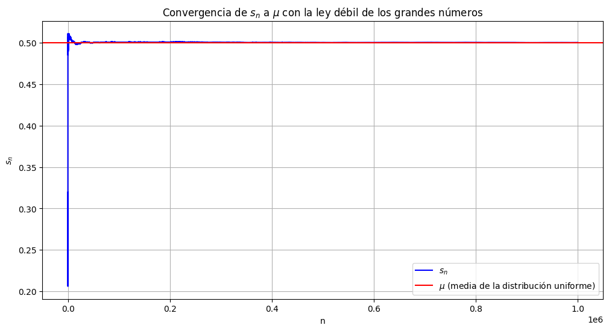

```python
# Graficar
plt.figure(figsize=(12, 6))
plt.plot(np.arange(1, n+1), s_n, label='$s_n$', color='blue')
plt.axhline(y=0.5, color='red', linestyle='-', label='$\mu$ (media de la distribución uniforme)')
plt.xlabel('n')
plt.ylabel('$s_n$')
plt.title('Convergencia de $s_n$ a $\mu$ con la ley débil de los grandes números')
plt.legend()
plt.grid(True)
plt.show()
```

La gráfica muestra la convergencia de la media aritmética parcial sn hacia la media μ de la distribución uniforme en el intervalo (0,1), que es 0.5. A medida que n crece, la función sn oscila alrededor de μ y se aproxima a este valor, demostrando así la ley débil de los grandes números.

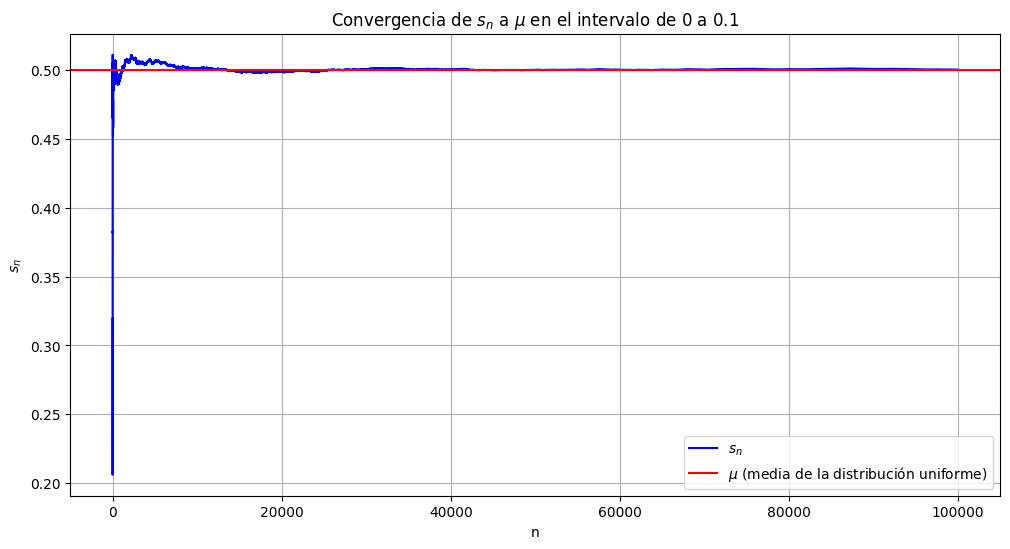

```python
# Acercamiento al intervalo de 0 a 0.1
plt.figure(figsize=(12, 6))
plt.plot(np.arange(1, int(n*0.1)+1), s_n[:int(n*0.1)], label='$s_n$', color='blue')
plt.axhline(y=0.5, color='red', linestyle='-', label='$\mu$ (media de la distribución uniforme)')
plt.xlabel('n')
plt.ylabel('$s_n$')
plt.title('Convergencia de $s_n$ a $\mu$ en el intervalo de 0 a 0.1')
plt.legend()
plt.grid(True)
plt.show()
```

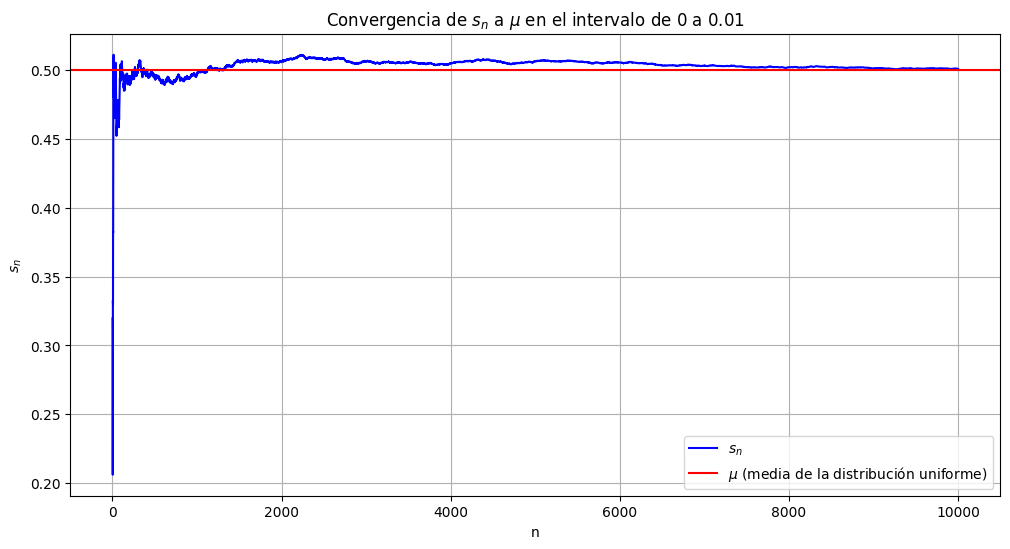

```python
# Acercamiento más pronunciado al intervalo de 0 a 0.01 (1% de los datos)
plt.figure(figsize=(12, 6))
plt.plot(np.arange(1, int(n*0.01)+1), s_n[:int(n*0.01)], label='$s_n$', color='blue')
plt.axhline(y=0.5, color='red', linestyle='-', label='$\mu$ (media de la distribución uniforme)')
plt.xlabel('n')
plt.ylabel('$s_n$')
plt.title('Convergencia de $s_n$ a $\mu$ en el intervalo de 0 a 0.01')
plt.legend()
plt.grid(True)
plt.show()
```

Cuando nos enfocamos en el intervalo de 0 a 0.01 (es decir, el 1% de los datos). Podemos observar que en los primeros valores de n, las oscilaciones de sn son aún más evidentes, pero aún así, incluso en esta etapa temprana, la media aritmética parcial comienza a aproximarse al valor μ.

# B

Teorema del límite central Para ello, se utilizará la distribución uniforme en el intervalo de (0,1). Sea µ la media de la distribución y sea σ^2 su varianza. Lleve a cabo las indicaciones de los siguientes incisos para:

n=20, 40, 60, 80, 100. N=50, 100, 1000, 10000.

1. Genere n valores independientes al azar x1,...,xn y calcule la media aritmética sn=1/n∑i=1 hasta n xi
2. Repita N veces el inciso anterior calculando los promedios centrados sn−µ/(σ/raiz(n)).
3. Elabore un histograma de estos N valores, trazando en la misma gráfica, la función de densidad normal estándar N(0,1). Utilice un tamaño adecuado para la base de los rectángulos.
4. Elabore una gráfica de la frecuencia relativa acumulada (función de distribución empírica) de los N valores uniendo los puntos con una línea recta y en la misma gráfica dibuje la función de distribución acumulada de N(0,1).

```python
from scipy.stats import norm
```

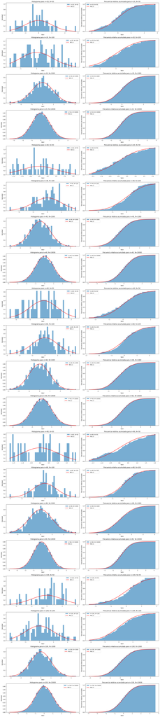

```python
# Parámetros de la distribución uniforme
mu = 0.5
sigma2 = 1/12
sigma = np.sqrt(sigma2)

# Valores de n y N
n_values = [20, 40, 60, 80, 100]
N_values = [50, 100, 1000, 10000]

# Función para generar los promedios centrados
def generate_centered_averages(n, N):
    averages = []
    for _ in range(N):
        x = np.random.uniform(0, 1, n)
        s_n = np.mean(x)
        centered_average = (s_n - mu) / (sigma / np.sqrt(n))
        averages.append(centered_average)
    return averages

# Histogramas y gráficas de distribución empírica
plt.figure(figsize=(18, len(n_values) * len(N_values) * 4))

count = 1
for n in n_values:
    for N in N_values:
        centered_averages = generate_centered_averages(n, N)

        # Histograma
        plt.subplot(len(n_values) * len(N_values), 2, count)
        count += 1
        plt.hist(centered_averages, bins=50, density=True, label=f'n={n}, N={N}', alpha=0.6)
        x = np.linspace(min(centered_averages), max(centered_averages), 1000)
        plt.plot(x, norm.pdf(x, 0, 1), 'r-', lw=2, label='N(0,1)')
        plt.title(f'Histograma para n={n}, N={N}')
        plt.xlabel('Valor')
        plt.ylabel('Densidad')
        plt.legend()

        # Frecuencia relativa acumulada
        plt.subplot(len(n_values) * len(N_values), 2, count)
        count += 1
        plt.hist(centered_averages, bins=50, density=True, cumulative=True, label=f'n={n}, N={N}', alpha=0.6)
        plt.plot(x, norm.cdf(x, 0, 1), 'r-', lw=2, label='N(0,1)')
        plt.title(f'Frecuencia relativa acumulada para n={n}, N={N}')
        plt.xlabel('Valor')
        plt.ylabel('Frecuencia relativa acumulada')
        plt.legend()

plt.tight_layout()
plt.show()
```

Como podemos observar, a medida que aumenta el valor de n (tamaño de la muestra), la distribución de los promedios centrados se asemeja más a la distribución normal estándar N(0,1) lo cual es una manifestación del Teorema del Límite Central. Además, a medida que N (número de repeticiones) aumenta, el histograma y la frecuencia relativa acumulada se estabilizan, proporcionando una representación más precisa de la distribución.